# Making your workflow reproducible

UMass Chan R Café

Emily C. Zabor

2025-10-24

## Hello

**Who am I?**

Associate Staff Biostatistician at the Cleveland Clinic in the Department of Quantitative Health Sciences and the Taussig Cancer Institute.

Applied cancer biostatistics and methods research in early phase oncology clinical trial design and methods for retrospective data analyses.

Checkout [my website](https://www.emilyzabor.com/tutorials/survival_analysis_in_r_tutorial.html) for more.

## Why am I here?

**Good question.**

1. This is not my area of expertise
2. But I have been doing data analysis projects in R for 15+ years
3. And I’ve learned a few things along the way
4. If *you* are an expert, chime in anytime!

## What will I cover today?

**How I try to make my project workflow reproducible, including:**

1. {starter} to create standard project frameworks
2. Folder structure and naming
3. RStudio projects and {here} package for portability
4. Quarto for reproducible reporting
5. {renv} for reproducible environments

## Context

Everything here evolved in the context of the work I do and how I do it.

1. Collaborate with doctors on clinical research projects: they send me data, I analyze it
2. Work independently as the only statistician/programmer for a given project
3. Patient data is sensitive
4. 2 and 3 mean nothing goes on GitHub
5. 2 also means that my interest in reproducibility is for future me and for sound science

## The {starter} package

[figure not shown]

“Provides a toolkit for starting new projects”

## Using {starter}: default settings

```r
# install.packages("starter")

starter::create_project(
  path = fs::path(tempdir(), "My Project Folder"),
  open = FALSE # don't open project in new RStudio session
)
```

```
✔ Using "Default Project Template" template
```

```
✔ Writing folder 'C:/Users/ZABORE2/AppData/Local/Temp/Rtmp6RUrNz/My Project Folder'
```

```
✔ Writing files "README.md", ".gitignore", "My Project Folder.Rproj", and ".Rprofile"
```

```
✔ Initialising Git repo
```

```
✔ Initialising renv project
```

```
- Lockfile written to "C:/Users/ZABORE2/AppData/Local/Temp/Rtmp6RUrNz/My Project Folder/renv.lock".
- renv infrastructure has been generated for project "C:/Users/ZABORE2/AppData/Local/Temp/Rtmp6RUrNz/My Project Folder".
```

## Resulting project structure

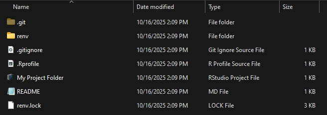

## Custom {starter} templates

The default is a great start, but I want a bit more:

1. Shell code files
2. Include Word reference document for Quarto

See the {starter} [website](https://www.danieldsjoberg.com/starter/articles/create_project.html#custom_template) for details on creating custom templates.

The R script that created my custom template is in my personal R package on GitHub [here](https://github.com/zabore/ezfun/blob/master/data-raw/project_template.R).

## Using {starter}: custom template

```r
# devtools::install_github("zabore/ezfun")

starter::create_project(
  path = fs::path(tempdir(), "example-custom-project"),
  template = ezfun::ez_analysis_template,
  open = FALSE
)
```

```
✔ Using "EZ Analysis Template" template
```

```
✔ Writing folder 'C:/Users/ZABORE2/AppData/Local/Temp/Rtmp6RUrNz/example-custom-project'
```

```
✔ Creating 'C:/Users/ZABORE2/AppData/Local/Temp/Rtmp6RUrNz/example-custom-project/code'
```

```
✔ Creating 'C:/Users/ZABORE2/AppData/Local/Temp/Rtmp6RUrNz/example-custom-project/code/templates'
```

```
✔ Writing files "README.md", ".gitignore", "example-custom-project.Rproj", ".Rprofile", "code/example-custom-project-munge.R", "code/example-custom-project-report.qmd", and "code/templates/doc_template.docx"
```

```
✔ Initialising Git repo
```

```
✔ Initialising renv project
```

```
- Lockfile written to "C:/Users/ZABORE2/AppData/Local/Temp/Rtmp6RUrNz/example-custom-project/renv.lock".
- renv infrastructure has been generated for project "C:/Users/ZABORE2/AppData/Local/Temp/Rtmp6RUrNz/example-custom-project".
```

## Resulting custom project structure

[figure not shown]

## Structure inside the code folder

[figure not shown]

## Munge file template

**Used for data cleaning and pre-processing**

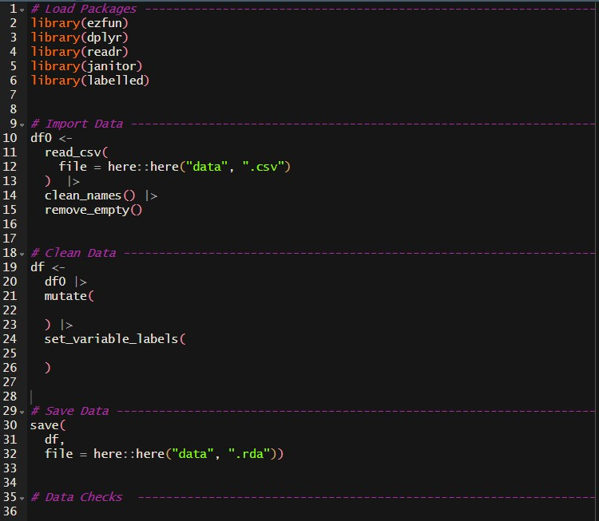

## Quarto file template

**Used for analysis and text**

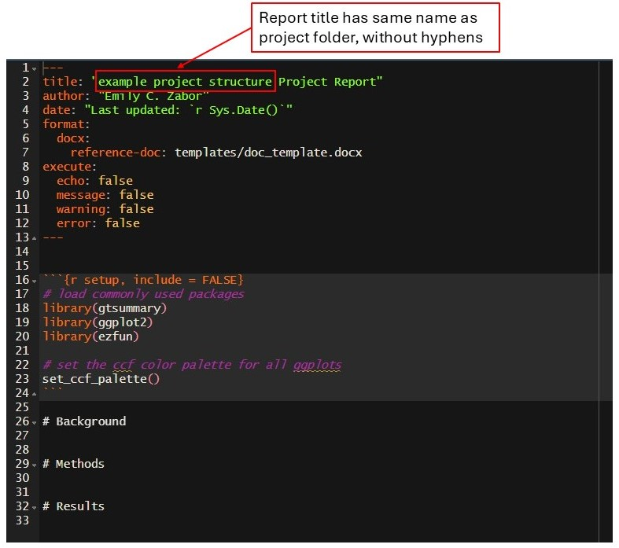

## Structure inside the templates folder

**Note how this was referenced in the YAML of the Quarto report**

[figure not shown]

See details on how to create your own reference document for Word output [here](https://quarto.org/docs/output-formats/ms-word-templates.html).

## Folder structure and naming

Find something that works for **you** and stick with it.

What I do as a collaborative biostatistician:

1. Store all project folders on the same drive, backed up by my organization
2. Each project gets its own folder
3. Name the folder as “PIName-brief-project-description”.
   - For example, a project with Jane Smith about treatment for metastatic breast cancer might be “Smith-metastatic-breast-trt”
4. Initialize using {starter}
5. Also add a “data” folder
6. Project reports produced by Quarto saved in main project folder as, e.g., “Smith-metastatic-breast-trt-report-2025-10-18” for version control

## RStudio projects

Benefits of working inside an RStudio project include:

- Start a fresh R session every time the project is opened
- The current working directory is set to the project directory
- Previously open R scripts are restored at project startup
- Other RStudio settings are restored
- Multiple RStudio sessions can be open at one time, running independently in different RStudio projects

## Creating RStudio projects

1. Automatically using the {starter} package
2. File menu in RStudio
3. Project menu in RStudio

## RStudio project from the file menu

[figure not shown]

## RStudio project from the file menu

[figure not shown]

## RStudio project from the file menu

[figure not shown]

## RStudio project from the project menu

[figure not shown]

## Workflow with RStudio project

[figure not shown]

## The {here} package

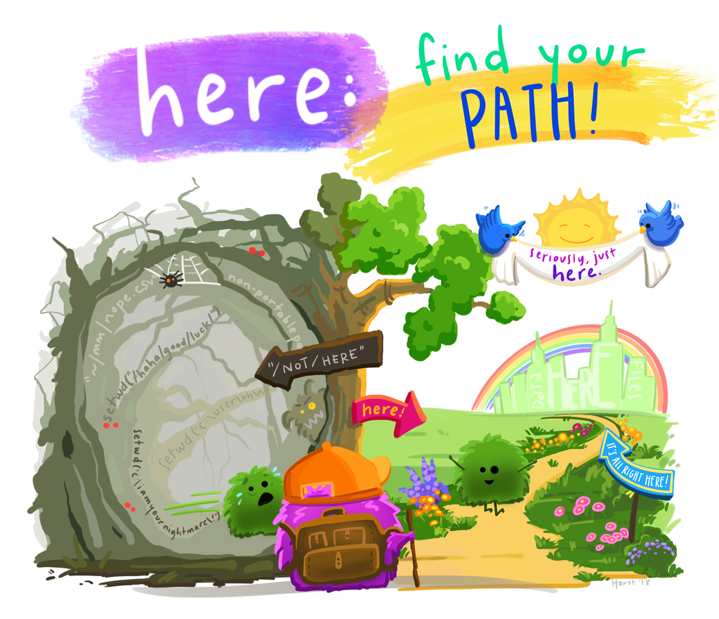

“Easy file referencing in project-oriented workflows”

## What does it do?

Creates paths relative to the top-level directory.

```r
# install.packages("here")

here::here()
```

```
[1] "C:/Users/ZABORE2/repos/zabore.github.io"
```

## How to use it: examples

**Read in data**

```r
# install.packages("readr")
df <- readr::read_csv(here::here("data", "mydata.csv"))
```

**Save files**

```r
myplot <- hist(rnorm(100))
save(here::here("plots", "myhistogram.jpg"))
```

## Quarto reports

- Started using RMarkdown reports, switched to Quarto.
- Very easy to switch and I still use a lot of RMarkdown style programming in my Quarto files.
- Never again:
  - hardcode a number
  - have separate documents for text and tables
  - manually create tables
  - have difficulty updating results when data change
- Easily mix code chunks with text
- Report numbers in-line in a programmatic way

## Separate files for data preparation and data reporting

Recall my starter template created two shell documents:

1. R script where data are cleaned and coded and saved into a .rda file
2. Quarto file where clean data are read in, analyses done, results reported

## What do I include?

I write my Quarto reports with four main sections:

1. **Notes/questions**: these are notes on things I did in the data cleaning process that I want to call attention to, i.e. how categories were combined, missing data to address, data issues or inconsistencies, etc
2. **Background**: a brief description of the problem or question being addressed by the project
3. **Methods**: A formal statistical methods section that can be copied and pasted directly into the eventual scientific publication
4. **Results**: Mostly tables and figures with some text interpretation mixed in.

## Quarto output options

- **html**: probably the most popular, with many customization options
- **pdf**: the trickiest to use, in my opinion, requires a LaTeX installation
- **Word**: unpopular, but my preference as it makes it easy to copy and paste entire tables and blocks of text from my report into the publication

**Note that you can also make slides in Quarto, like these slides, but that is not our focus today**

## Components of a Quarto file

1. The YAML header
2. Code chunks
3. Markdown text

## The YAML header

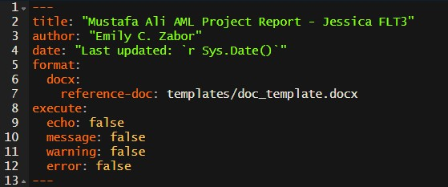

## Code chunks

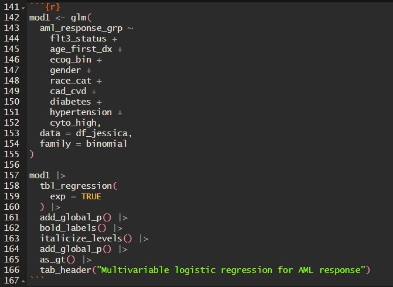

## Markdown text

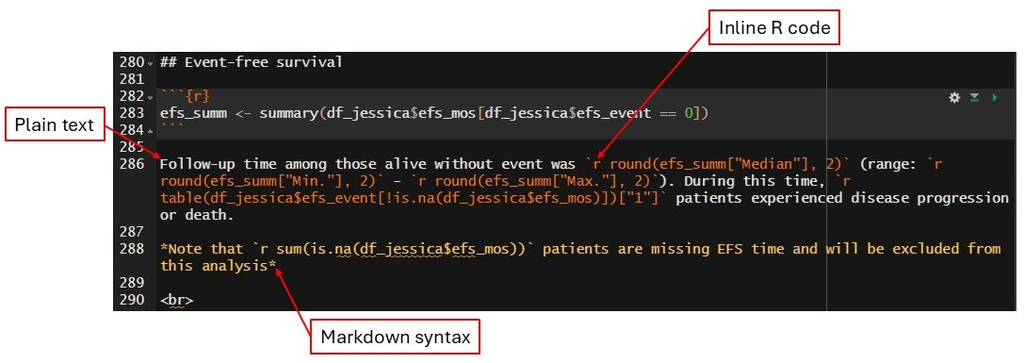

## Rendering

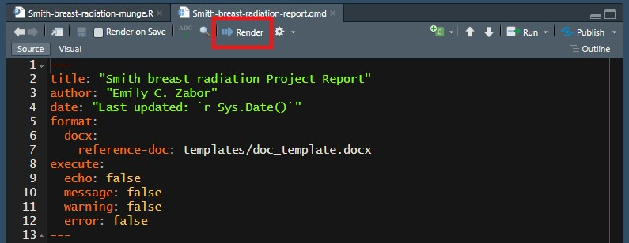

- This places the output file inside the same folder where the .qmd file is saved, in this case in the code folder
- I always “Save As” to the main project folder with the date of the file creation for version control

## The {renv} package

[figure not shown]

“create reproducible environments for your R projects”

## Initialize the project

First run `renv::init()` to initialize a new library. This was done for us with `starter::create_project()`.

[figure not shown]

## Other {renv} functions

- `install()` to install packages from CRAN, GitHub, or Bioconductor
- `update()` gets the latest versions of all dependencies

For collaboration with others:

- `snapshot()` adds metadata about currently used packages to the lockfile
- `restore()` uses metadata from the lockfile to install exactly the same version of every package

## Put it all together

**Case study**: I am starting a new project with Dr. Jane Smith about the association between radiation treatment and overall survival in women with breast cancer. Dr. Smith has emailed me an Excel dataset to analyze for the project, and we have discussed the analysis plan.

## Run `starter::create_project()`

```r
starter::create_project(
  path = fs::path("G:/StatTeam/zabore/Smith-breast-radiation"),
  template = ezfun::ez_analysis_template,
  open = FALSE
)
```

```
✔ Using "EZ Analysis Template" template
```

```
✔ Writing files
```

```
✔ Initialising renv project
```

```
- Lockfile written to "G:/StatTeam/zabore/Smith-breast-radiation/renv.lock".
- renv infrastructure has been generated for project "G:/StatTeam/zabore/Smith-breast-radiation".
```

Notes:

- “G:/StatTeam/zabore” is my organization’s preferred and backed-up drive on my computer
- A new project folder named “Smith-breast-radiation” will be created and populated

[figure not shown]

## Add a data folder and save the data there

- The investigator sent me an Excel file, which I save as is
- I also “Save As” a csv, which I’ll import to R for data cleaning

[figure not shown]

## Open the RStudio project

Once in the RStudio project:

- Open the two shell files (R script and qmd)
- Start to install needed packages using `renv::install()`

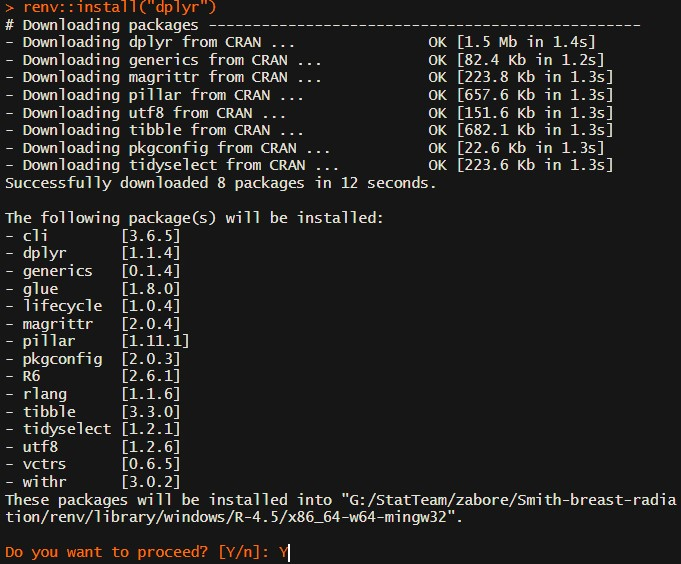

## Read in, clean up, and save the data

- This is one place where the {here} package will come in handy

```r
library(dplyr)
library(readr)

# Import data ------------------------------------
df0 <-
  read_csv(
    file = here::here("data", "breastcancer.csv")
  )  |>
  janitor::clean_names() |>
  janitor::remove_empty()

# Clean data -------------------------------------
df <-
  df0 |>
  mutate(
    # Insert data cleaning steps here
  ) |>
  labelled::set_variable_labels(
    # Insert variable labels here
  )

# Save the data ----------------------------------
save(
  df,
  file = here::here("data", "smith-breast-rt-data.rda"))
```

## Analyze and report in Quarto

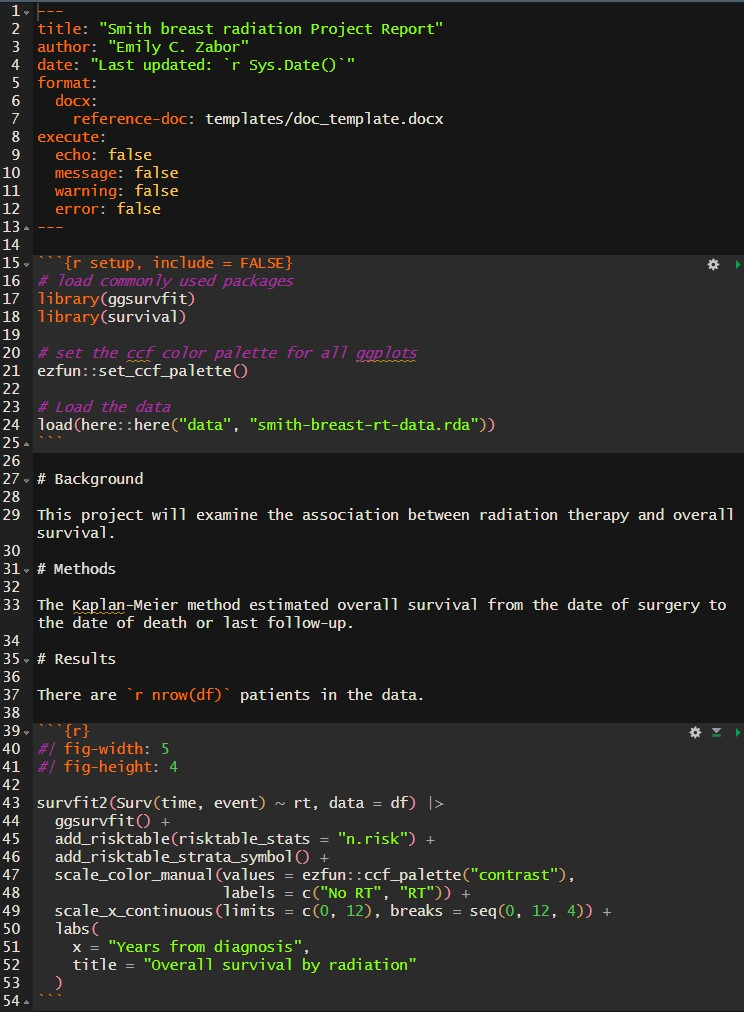

## View the resulting report

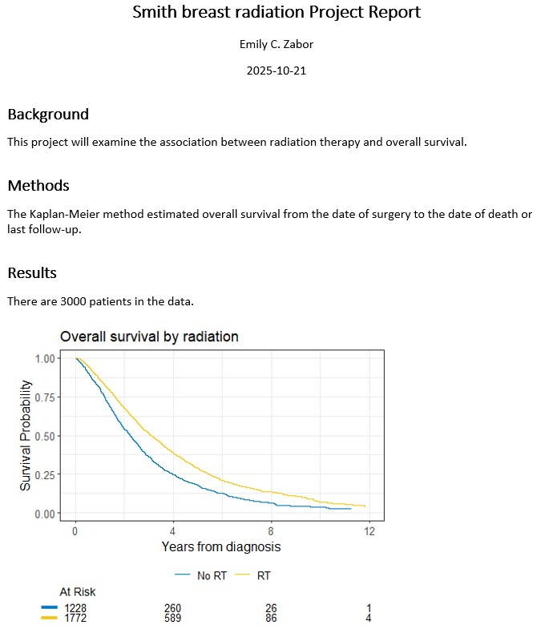

## Save the report with a new name

[figure not shown]

## Thank you

**Connect with me:**

zabore2@ccf.org

https://www.emilyzabor.com/

https://github.com/zabore

https://www.linkedin.com/in/emily-zabor-59b902b7/

https://bsky.app/profile/zabore.bsky.social/